# Movies Dataset Analysis

```python
import pandas as pd
import matplotlib.pyplot as plt
import seaborn as sns
```

```python
df = pd.read_csv("Movies Dataset.csv")
```

```python
df.head()  # Show first 5 rows
```

|  | id | title | genres | original_language | overview | popularity | production_companies | release_date | budget | revenue | runtime | status | tagline | vote_average | vote_count | credits | keywords | poster_path | backdrop_path | recommendations |
| --- | --- | --- | --- | --- | --- | --- | --- | --- | --- | --- | --- | --- | --- | --- | --- | --- | --- | --- | --- | --- |
| 0 | 385687 | Fast X | Action-Crime-Thriller | en | Over many missions and against impossible odds... | 6682.100 | Universal Pictures-Original Film-One Race-Perf... | 2023-05-17 | 340000000.0 | 6.867000e+08 | 142.0 | Released | The end of the road begins. | 7.331 | 1856.0 | Vin Diesel-Michelle Rodriguez-Tyrese Gibson-Lu... | sequel-revenge-racing-family-cars | /fiVW06jE7z9YnO4trhaMEdclSiC.jpg | /4XM8DUTQb3lhLemJC51Jx4a2EuA.jpg | 19603-445954-697843-603692-781009-502356-74735... |
| 1 | 758323 | The Pope's Exorcist | Horror-Mystery-Thriller | en | Father Gabriele Amorth Chief Exorcist of the V... | 5953.227 | Screen Gems-2.0 Entertainment-Jesus & Mary-Wor... | 2023-04-05 | 18000000.0 | 6.567582e+07 | 103.0 | Released | Inspired by the actual files of Father Gabriel... | 7.433 | 545.0 | Russell Crowe-Daniel Zovatto-Alex Essoe-Franco... | spain-rome italy-vatican-pope-pig-possession-c... | /9JBEPLTPSm0d1mbEcLxULjJq9Eh.jpg | /hiHGRbyTcbZoLsYYkO4QiCLYe34.jpg | 713704-296271-502356-1076605-1084225-1008005-9... |
| 2 | 640146 | Ant-Man and the Wasp: Quantumania | Action-Adventure-Science Fiction | en | Super-Hero partners Scott Lang and Hope van Dy... | 4425.387 | Marvel Studios-Kevin Feige Productions | 2023-02-15 | 200000000.0 | 4.757662e+08 | 125.0 | Released | Witness the beginning of a new dynasty. | 6.507 | 2811.0 | Paul Rudd-Evangeline Lilly-Jonathan Majors-Kat... | hero-ant-sequel-superhero-based on comic-famil... | /qnqGbB22YJ7dSs4o6M7exTpNxPz.jpg | /m8JTwHFwX7I7JY5fPe4SjqejWag.jpg | 823999-676841-868759-734048-267805-965839-1033... |
| 3 | 677179 | Creed III | Drama-Action | en | After dominating the boxing world Adonis Creed... | 3994.342 | Metro-Goldwyn-Mayer-Proximity Media-Balboa Pro... | 2023-03-01 | 75000000.0 | 2.690000e+08 | 116.0 | Released | You can't run from your past. | 7.262 | 1129.0 | Michael B. Jordan-Tessa Thompson-Jonathan Majo... | philadelphia pennsylvania-husband wife relatio... | /cvsXj3I9Q2iyyIo95AecSd1tad7.jpg | /5i6SjyDbDWqyun8klUuCxrlFbyw.jpg | 965839-267805-943822-842942-1035806-823999-107... |
| 4 | 502356 | The Super Mario Bros. Movie | Animation-Family-Adventure-Fantasy-Comedy | en | While working underground to fix a water main ... | 3859.926 | Universal Pictures-Illumination-Nintendo | 2023-04-05 | 100000000.0 | 1.278767e+09 | 92.0 | Released | NaN | 7.764 | 4042.0 | Chris Pratt-Charlie Day-Anya Taylor-Joy-Jack B... | video game-gorilla-plumber-magic mushroom-anth... | /qNBAXBIQlnOThrVvA6mA2B5ggV6.jpg | /2klQ1z1fcHGgQPevbEQdkCnzyuS.jpg | 713704-385687-640146-60898-758323-1008005-4935... |

## Movie Dataset Overview

This dataset contains information about movies, including:

- **Title**: The name of the movie.
- **Genres**: The categories the movie belongs to (e.g., Action, Comedy, Drama).
- **Release Date**: The date the movie was released.
- **Budget**: The estimated production cost of the movie.
- **Revenue**: The total earnings of the movie.
- **Runtime**: The length of the movie in minutes.
- **Vote Average**: The average user rating for the movie.
- **Production Companies**: The company responsible for producing the movie.

We will analyze trends in genres, revenue, and ratings to better understand the movie industry.

# Data Analysis

### 1. Data Structure

```python
df.info()  # Check column types and missing values
df.describe()  # Summary statistics
```

```
<class 'pandas.core.frame.DataFrame'>
RangeIndex: 722796 entries, 0 to 722795
Data columns (total 20 columns):
 #   Column                Non-Null Count   Dtype
---  ------                --------------   -----
 0   id                    722796 non-null  int64
 1   title                 722790 non-null  object
 2   genres                511934 non-null  object
 3   original_language     722796 non-null  object
 4   overview              604198 non-null  object
 5   popularity            722796 non-null  float64
 6   production_companies  337170 non-null  object
 7   release_date          670329 non-null  object
 8   budget                722796 non-null  float64
 9   revenue               722796 non-null  float64
 10  runtime               688346 non-null  float64
 11  status                722796 non-null  object
 12  tagline               108098 non-null  object
 13  vote_average          722796 non-null  float64
 14  vote_count            722796 non-null  float64
 15  credits               497689 non-null  object
 16  keywords              210271 non-null  object
 17  poster_path           537566 non-null  object
 18  backdrop_path         222524 non-null  object
 19  recommendations       34720 non-null   object
dtypes: float64(6), int64(1), object(13)
memory usage: 110.3+ MB
```

|  | id | popularity | budget | revenue | runtime | vote_average | vote_count |
| --- | --- | --- | --- | --- | --- | --- | --- |
| count | 722796.000000 | 722796.000000 | 7.227960e+05 | 7.227960e+05 | 6.883460e+05 | 722796.000000 | 722796.000000 |
| mean | 526917.587990 | 1.807185 | 3.924801e+05 | 9.776385e+05 | 1.989186e+02 | 2.443118 | 27.610661 |
| std | 253164.471522 | 18.839397 | 8.136181e+06 | 2.010908e+07 | 8.581987e+04 | 3.175498 | 381.523676 |
| min | 2.000000 | 0.600000 | 0.000000e+00 | -1.200000e+01 | 0.000000e+00 | 0.000000 | 0.000000 |
| 25% | 328947.750000 | 0.600000 | 0.000000e+00 | 0.000000e+00 | 5.000000e+00 | 0.000000 | 0.000000 |
| 50% | 533364.500000 | 0.600000 | 0.000000e+00 | 0.000000e+00 | 5.000000e+01 | 0.000000 | 0.000000 |
| 75% | 737817.250000 | 1.290000 | 0.000000e+00 | 0.000000e+00 | 9.000000e+01 | 5.600000 | 2.000000 |
| max | 968161.000000 | 6682.100000 | 5.000000e+09 | 2.920357e+09 | 5.050505e+07 | 10.000000 | 33262.000000 |

## Dataset Overview

This dataset contains **722,796 movies** with **20 columns**, covering details like title, genres, budget, revenue, ratings, and production companies. Several columns have missing values, notably **genres, production companies, and release date**.

### **Key Insights**

#### **Numerical Summary**

[output not shown]

#### **Observations**

- Many movies have **missing or zero budget and revenue**, affecting analysis.
- **Popularity is highly skewed**, with a few blockbuster films dominating.
- **Vote counts are low for most movies**, indicating limited audience engagement.
- **Extreme runtime values** suggest data entry errors.

### **Next Steps**

- **Identify zero values** in key columns.
- **Filter out extreme outliers** for better insights.
- **Analyze trends** in revenue, genres, and ratings.

This dataset is valuable but requires cleaning before deeper analysis.

### 2. Check for missing data

```python
df.isnull().sum()
```

```
id                           0
title                        6
genres                  210862
original_language            0
overview                118598
popularity                   0
production_companies    385626
release_date             52467
budget                       0
revenue                      0
runtime                  34450
status                       0
tagline                 614698
vote_average                 0
vote_count                   0
credits                 225107
keywords                512525
poster_path             185230
backdrop_path           500272
recommendations         688076
dtype: int64
```

```python
pip install matplotlib seaborn
```

# Visualizations

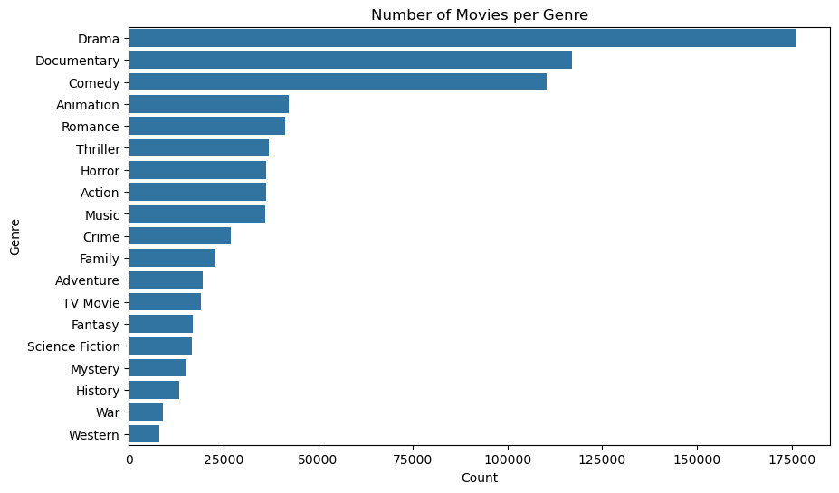

```python
# First, split genres by hyphen and expand into multiple rows
genres_expanded = df['genres'].str.split('-', expand=True).stack().reset_index(level=1, drop=True)
genres_expanded.name = 'genre'

# Now plot the counts of each genre
plt.figure(figsize=(10,6))
sns.countplot(y=genres_expanded, order=genres_expanded.value_counts().index)
plt.title("Number of Movies per Genre")
plt.xlabel("Count")
plt.ylabel("Genre")
plt.show()
```

### Number of Movies per Genre

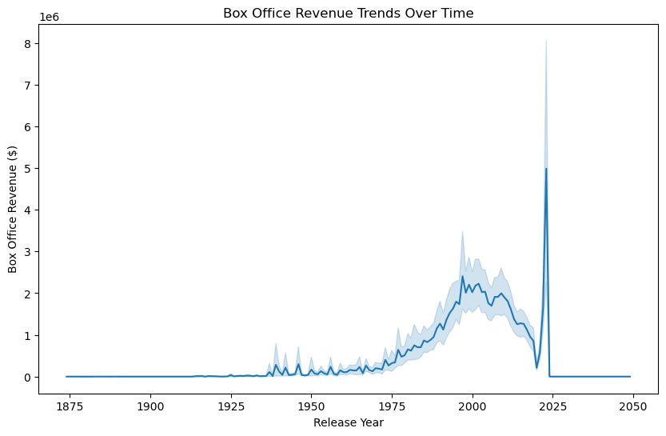

```python
plt.figure(figsize=(10,6))
sns.lineplot(x="release_year", y="revenue", data=df)
plt.title("Box Office Revenue Trends Over Time")
plt.xlabel("Release Year")
plt.ylabel("Box Office Revenue ($)")
plt.show()
```

### Box Office Revenue Over Time

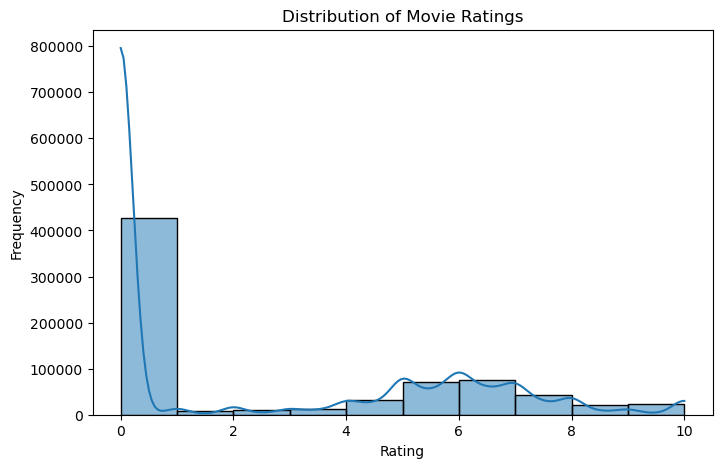

```python
plt.figure(figsize=(8,5))
sns.histplot(df["vote_average"], bins=10, kde=True)
plt.title("Distribution of Movie Ratings")
plt.xlabel("Rating")
plt.ylabel("Frequency")
plt.show()
```

### Distribution of Movie Ratings

# Key Findings